# Quantifying Uncertainty: Evaluating Trading Algorithms using Probabilistic Programming

## Thomas Wiecki

## Quantopian Inc.

# About me

- PhD from Brown University -- research on computational neuroscience and machine learning using Bayesian modeling.
- Quantitative Researcher at [Quantopian Inc](https://www.quantopian.com): Building the world's first algorithmic trading platform in the web browser.
- @twiecki on Twitter.

# Outline

1. Motivation / Problem: Identify stellar quants with limited data
2. The naive approach: point estimates
3. Quick primer on Random Variables and Bayesian statistics
4. Quantifying uncertainty
5. Including prior knowledge
6. Hierarchical modeling

# 1. Motivation

[figure not shown]

## Live Trading

[figure not shown]

## Crowd-sourced hedge fund

[figure not shown]

# The naive approach

Use one of the many risk metrics that people have devised, like the Sharpe ratio:

$$\text{Sharpe} = \frac{\text{returns}}{\text{volatility}}$$

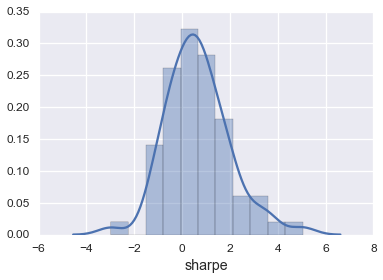

```python
sns.distplot(hier_df.groupby('live_algo_id').last().sharpe)
```

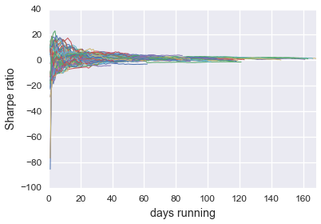

```python
for algo_id, df_algo in df.groupby(level=0):
    df_algo.reset_index().sharpe.plot(lw=1)
plt.xlabel('days running')
plt.ylabel('Sharpe ratio')
```

# 2. Short primer on random variables

- Represents our beliefs about an unknown state.
- Probability distribution assigns a probability to each possible state.
- **Not** a single number (e.g. most likely state).

## You already know what a variable is...

```python
coin = 0 # 0 for tails
coin = 1 # 1 for heads
```

## A random variable assigns all possible values a certain probability

```python
coin = {0: 50%,
        1: 50%}
```

### Alternatively:

coin ~ Bernoulli(p=0.5)

- `coin` is a random variable
- `Bernoulli` is a probability distribution
- `~` reads as "is distributed as"

## This was discrete (binary), what about the continuous case?

returns ~ Normal($\mu$, $\sigma^2$)

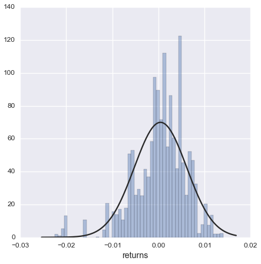

```python
from scipy import stats
sns.distplot(df.benchmark, kde=False, fit=stats.norm)
plt.xlabel('returns')
```

# How to estimate $\mu$ and $\sigma$?

- Naive: point estimate
- Set `mu = np.mean(data)` and `sigma = np.std(data)`
- Maximum Likelihood Estimate
- Correct answer as $n \rightarrow \infty$

# Bayesian analysis

- Most of the time $n \neq \infty$...
- *Uncertainty* about $\mu$ and $\sigma$
- Turn $\mu$ and $\sigma$ into random variables
- How to estimate?

# Bayes Formula!

[figure not shown]

Use prior knowledge and data to update our *beliefs*.

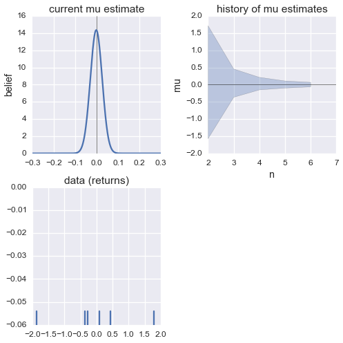

```python
interactive(gen_plot, n=(0, 600), bayes=True)
```

# Probabilistic Programming

- Model **unknown causes** (e.g. $\mu$) of a phenomenon as **random variables**.
- Write a **programmatic story** of how **unknown causes** result in **observable data**.
- Use **Bayes formula** to invert generative model to infer **unknown causes**.

## Approximating the posterior with MCMC sampling

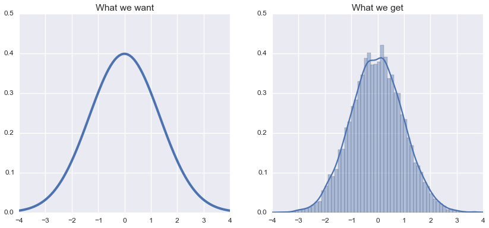

```python
plot_want_get()
```

# PyMC3

- Probabilistic Programming framework written in Python.
- Allows for construction of probabilistic models using intuitive syntax.
- Features advanced MCMC samplers.
- Fast: Just-in-time compiled by Theano.
- **Extensible**: easily incorporates custom MCMC algorithms and unusual probability distributions.
- Authors: John Salvatier, Chris Fonnesbeck, Thomas Wiecki
- Still in *alpha* (lack of documentation)!

## Lets select a single algorithm to work with.

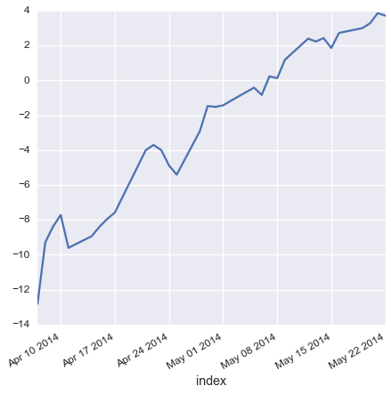

```python
algo_df.sharpe.plot()
```

## Statistical model

$\mu \sim normal(0, 1)$

$\sigma \sim gamma(0.01, 2)$

$returns \sim normal(\mu, \sigma^2)$

$Sharpe = \frac{\mu}{\sigma}$

## Graphical model of returns

[figure not shown]

## This is what the data looks like

```python
print returns_data
```

```
[ 0.00021801  0.00065388  0.00272272 ..., -0.00572433  0.00782789
 -0.0161355 ]
```

```python
import pymc as pm

with pm.Model() as model:
    # Priors on Random Variables
    mean_return = pm.Normal('mean return', mu=0, sd=1)
    volatility = pm.Gamma('volatility', mu=.01, sd=2)

    # Model returns as Normal
    obs = pm.Normal('returns',
                    mu=mean_return,
                    sd=volatility,
                    observed=returns_data)

    sharpe = pm.Deterministic('sharpe ratio',
                              (mean_return / volatility) * np.sqrt(252) )
```

```python
with model:
    # Instantiate MCMC sampler
    step = pm.NUTS()
    # Draw 500 samples from the posterior
    trace = pm.sample(500, step)
```

```
 [-----------------100%-----------------] 500 of 500 complete in 0.4 sec
```

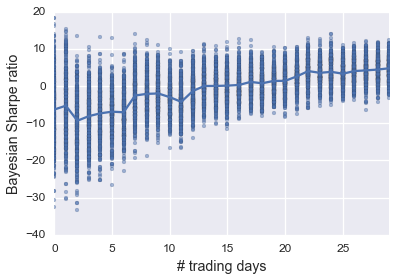

```python
sns.tsplot(b_sharpe, err_style='unit_points', interpolate=True)
plt.xlabel('# trading days')
plt.ylabel('Bayesian Sharpe ratio');
```

```python
print 'P(Sharpe Ratio > 0) = %.2f%%' % \
    (np.mean(trace['sharpe ratio'] > 0) * 100)
```

```
P(Sharpe Ratio > 0) = 95.40%
```

## Prior knowledge

```python
bmark_mean = df.bmark_rf.mean()
bmark_sd = df.bmark_rf.std()

with pm.Model() as model:
    # Priors on Random Variables
    mean_return = pm.Normal('mean return', mu=bmark_mean, sd=.001)
    volatility = pm.Gamma('volatility', mu=bmark_sd, sd=.001)

    # Model returns as Normal
    returns = pm.Normal('returns',
                        mu=mean_return,
                        sd=volatility,
                        observed=returns_data)

    sharpe = pm.Deterministic('sharpe ratio',
                              (mean_return / volatility) * np.sqrt(252) )
```

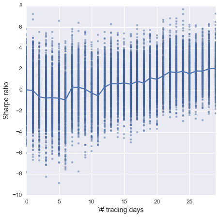

```python
sns.tsplot(b_sharpe_info, err_style='unit_points', interpolate=True)
plt.xlabel('# trading days')
plt.ylabel('Sharpe ratio');
```

# Analysing multiple algorithms

Easy! Compute Bayesian Sharpe ratio for each algorithm.

# Unpooled

[figure not shown]

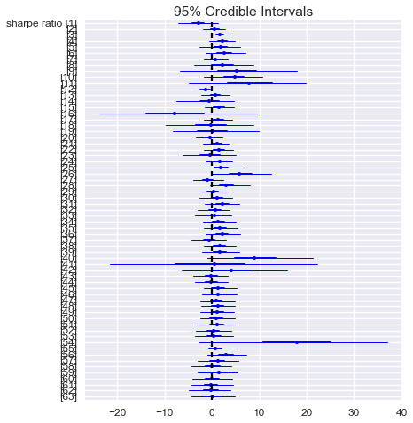

```python
pm.forestplot(trace_unpooled, vars=['sharpe ratio']);
```

# Partially pooled -- hierarchical

[figure not shown]

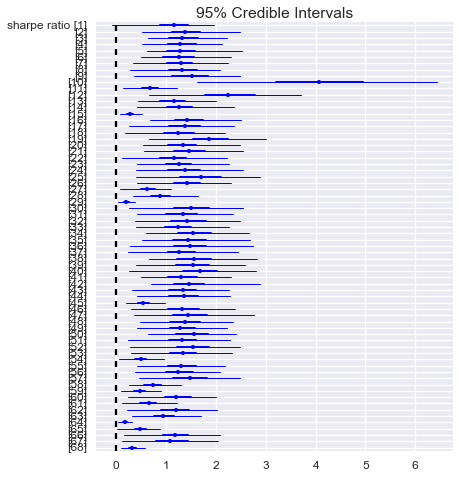

```python
pm.forestplot(trace_hier[50:], vars=['sharpe ratio'])
```

# Conclusions

- **Bayesian statistics** allows us to **quantify uncertainty** and make use of **prior knowledge**.
- Idea of Bayesian Sharpe ratio can easily be applied to other risk metrics or non-finance related data.
- **Blackbox inference algorithms** allow estimation of **complex models**.
- **PyMC3** puts **advanced samplers** at your fingertips.

# Further reading

- [Quantopian](https://www.quantopian.com) -- Develop trading algorithms like this in your browser.
- [My blog for Bayesian linear regression (financial alpha and beta)](https://twiecki.github.io)
- [Probilistic Programming for Hackers](http://camdavidsonpilon.github.io/Probabilistic-Programming-and-Bayesian-Methods-for-Hackers/) -- IPython Notebook book on Bayesian stats using PyMC2.
- [Doing Bayesian Data Analysis](http://www.indiana.edu/~kruschke/DoingBayesianDataAnalysis/) -- Great book by Kruschke.
- [PyMC3 repository](https://github.com/pymc-devs/pymc)
- Twitter: [@twiecki](https://twitter.com/twiecki)